# Data Science Pipeline Tutorial

## A Comparision of Hate crimes on college campuses vs. Cities

### By Tejan Gandhi

Hate crimes against minorities are becoming increasingly troublesome and they not only affect mental health, but recent events have uncovered the systemic aspect of discrimination against minorities. College is a controlled, safe environment that enables students to explore and express freely, all aspects of themselves and gives a sense of freedom. However, as we will see in this analysis, hate crimes start from college level. College shapes who you will be as an adult and therefore it is very important to teach students not to discriminate, and keep colleges the safe spaces that the students from all accross the world desire. And therefore it is important to analyze the hate crimes happening in colleges.

### What this project aims to do

This project is an introduction walkthrough to the data science pipeline. It covers various steps such as data mining, preprocessing and cleaning, exploratory data analysis, Hypothesis testing and machine learning, and insight communication. I will be working on FBI hate crime statistics report for 2013, that illustrates the hate crimes commited accross various genders, persons with disabilities, people with color and other minorities, in different cities, states, and community settings. It can be obtained via wget from this link: https://raw.githubusercontent.com/emorisse/FBI-Hate-Crime-Statistics/master/2013/table13.csv

```python
# Necessary imports
import numpy as np
import pandas as pd
import math
import matplotlib.pyplot as plt
import seaborn as sns
import sklearn
```

## Understanding how the data is stored

This table presents the data from those agencies that reported one or more hate crime incidents occurred in their respective jurisdictions during 1 or more quarters in 2013. The data are distributed by bias motivation and quarter. You can read more about this dataset here: https://github.com/emorisse/FBI-Hate-Crime-Statistics/tree/master/2013.  
We can see how the data is stored and what information is provided in this data, so that cleaning up process is easier.

```python
# Reading the data from csv file.
df = pd.read_csv("table13.csv")
```

This is how the first 5 rows of the table look like:

```python
df.head()
```

|  | State | Agency type | Agency name | Race | Religion | Sexual orientation | Ethnicity | Disability | Gender | Gender Identity | 1st quarter | 2nd quarter | 3rd quarter | 4th quarter | Population |
| --- | --- | --- | --- | --- | --- | --- | --- | --- | --- | --- | --- | --- | --- | --- | --- |
| 0 | Alabama | Cities | Florence | 2 | 0 | 0 | 0 | 0 | 0 | 0.0 | 0.0 | 1.0 | 0.0 | 1.0 | 39,481 |
| 1 | Alabama | Cities | Hoover | 0 | 0 | 1 | 0 | 0 | 0 | 0.0 | 0.0 | 1.0 | 0.0 | 0.0 | 84,139 |
| 2 | Alabama | Cities | Prattville | 2 | 0 | 0 | 0 | 0 | 0 | 0.0 | 1.0 | 0.0 | 1.0 | 0.0 | 35,154 |
| 3 | Alabama | Cities | Tuscaloosa | 1 | 0 | 0 | 0 | 0 | 0 | 0.0 | 0.0 | 0.0 | 1.0 | 0.0 | 94,126 |
| 4 | Alaska | Cities | Anchorage | 8 | 0 | 0 | 0 | 0 | 0 | 0.0 | 2.0 | 3.0 | 3.0 | 0.0 | 299,455 |

The first column has states in which crimes are described, followed by agency types. There are 6 unique agency types as verified below by code. The next column indicates the agency name, i.e., city name or university name. Next few columns mention the characteristics of the victim. Next new columns represent the quarters in 2013 these crimes took place. Finally, the last column describes the population of the agency.

## Cleaning the data

```python
cols = df.columns
cols = cols.map(lambda x: x.replace(' ', '_') if isinstance(x, (str)) else x)
df.columns = cols
# this command above will change the names of columns to be valid python identifiers
x = df.Agency_type.unique()
print(len(x))
```

```
6
```

Additionally the population is given in string format, and for our purposes, we might need to convert that into integer type, since it'll be useful in the future. So we will convert the data type of Population to integer.

```python
new_pop_list = []
for num in list(df.Population):
    if (type(num) == type("hello") and num.lower() == "nan") or (type(num) != type("string") and math.isnan(num)):
        new_pop_list.append(np.nan)
    else:
        new_pop_list.append(int(num.replace(",", "")))
```

```python
df["Population"] = new_pop_list
```

## Accounting for missing data

Before dropping the values, there were 1826 rows in the DataFrame. After dropping, there are only 1372 rows, the dropped row had a missing value in any one way.

```python
len(df)
```

```
1826
```

```python
df = df.dropna()
```

## Exploratory Data Analysis

### Performing analysis among the different characteristics

First I will group the data by agency types and then I will plot different graphs to compare the hate crimes.

```python
df_groupedby_agency_type = df.groupby(['Agency_type']).sum()
df_gat = df_groupedby_agency_type
df_gat
```

| Agency_type | Race | Religion | Sexual_orientation | Ethnicity | Disability | Gender_Identity | 1st_quarter | 2nd_quarter | 3rd_quarter | 4th_quarter | Population |
| --- | --- | --- | --- | --- | --- | --- | --- | --- | --- | --- | --- |
| Cities | 2198 | 759 | 980 | 477 | 63 | 28.0 | 963.0 | 1283.0 | 1259.0 | 1016.0 | 104456696.0 |
| Universities and Colleges | 85 | 37 | 49 | 10 | 1 | 1.0 | 47.0 | 37.0 | 40.0 | 63.0 | 1798097.0 |

```python
df.Population.sum()
```

```
106254793.0
```

```
Hate crimes in the social organizations: Cities
```

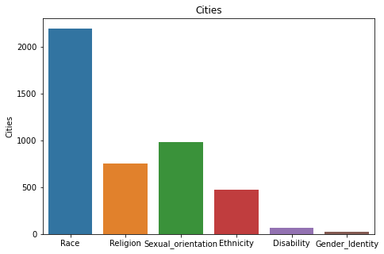

```
Hate crimes in the social organizations: Universities and Colleges
```

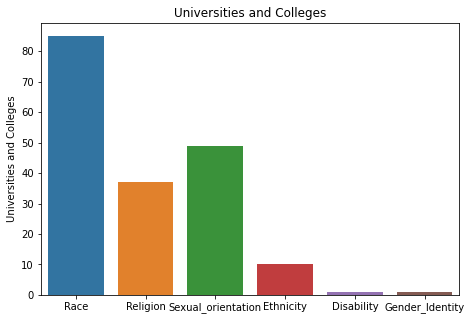

```python
for i in range(2):
    print("Hate crimes in the social organizations: {}".format(df_gat.index[i]))
    x = pd.DataFrame(df_gat.iloc[i][0:6])
    fig, ax = plt.subplots(figsize=(7.5, 5))
    sns.barplot(ax = ax, y = x[df_gat.index[i]], x = x.index).set_title(df_gat.index[i])
    plt.show()
```

#### Analysis:

As it is apparent from the graphs, racial hate crimes are highest among all the different social settings, followed by religion and sexual orientation in, followed by ethnicity. Disability and gender identity victims are not many, but the value is still not entirely zero in some social settings.

### Comparing the hate crimes accross Universities and Cities.

```python
x_temp = {"Numbers" : [df_gat.iloc[0][0:6].sum(), df_gat.iloc[1][0:6].sum()]}
x_later = [df_gat.iloc[0][0:6].sum()/df_gat.iloc[0]["Population"], df_gat.iloc[1][0:6].sum()/df_gat.iloc[1]["Population"]]
```

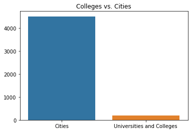

```python
sns.barplot(y = x_temp["Numbers"], x = ["Cities", "Universities and Colleges"]).set_title("Colleges vs. Cities")
```

From this graph, it looks like the Universities and Colleges are indeed much safer places in terms of hate crime incidents. However, the populatiom of both places vary significantly too. This is how they look after scaling them proportionately.

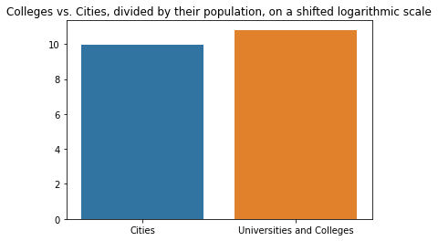

```python
x_temp["Numbers"][0] /= df_gat.iloc[0]["Population"]
x_temp["Numbers"][1] /= df_gat.iloc[1]["Population"]
x_temp["Numbers"][0] = 20 + np.log(x_temp["Numbers"][0])
x_temp["Numbers"][1] = 20 + np.log(x_temp["Numbers"][1])
sns.barplot(y = x_temp["Numbers"], x = ["Cities", "Universities and Colleges"]).set_title("Colleges vs. Cities, divided by their population, on a shifted logarithmic scale")
```

```python
print("Probability that hate crime incident will happen in a city: {}". format(x_later[0]))
print("Probability that hate crime incident will happen in a college: {}". format(x_later[1]))
```

```
Probability that hate crime incident will happen in a city: 4.312791972665879e-05
Probability that hate crime incident will happen in a college: 0.00010177426468093768
```

It is much more likely that a hate crime will happen to you in the college than in a normal city. It sounds horrifying.

### EDA on crime rates by quarters.

```python
df_gat
```

| Agency_type | Race | Religion | Sexual_orientation | Ethnicity | Disability | Gender_Identity | 1st_quarter | 2nd_quarter | 3rd_quarter | 4th_quarter | Population |
| --- | --- | --- | --- | --- | --- | --- | --- | --- | --- | --- | --- |
| Cities | 2198 | 759 | 980 | 477 | 63 | 28.0 | 963.0 | 1283.0 | 1259.0 | 1016.0 | 104456696.0 |
| Universities and Colleges | 85 | 37 | 49 | 10 | 1 | 1.0 | 47.0 | 37.0 | 40.0 | 63.0 | 1798097.0 |

```
Hate crimes in the social organizations: Cities
```

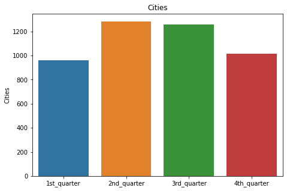

```
Hate crimes in the social organizations: Universities and Colleges
```

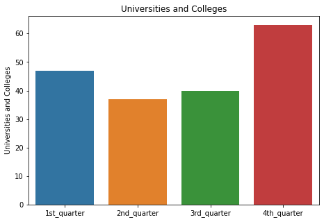

```python
for i in range(2):
    print("Hate crimes in the social organizations: {}".format(df_gat.index[i]))
    x = pd.DataFrame(df_gat.iloc[i][6:-1])
    fig, ax = plt.subplots(figsize=(7.5, 5))
    sns.barplot(ax = ax, y = x[df_gat.index[i]], x = x.index).set_title(df_gat.index[i])
    plt.show()
```

Cities have higher rates of hate crimes in April to September time period, whereas Universities have higher rates of hate crimes in the time period October to December.

### EDA on crime rates by states

Again, since the populations are very different it will be ideal to divide the statistics by population. But since the quotients will be very large, I will divide the values by population / 10,000.

```python
df_gbstate = df.groupby("State").sum()
df_gbstate["Race"] = df_gbstate["Race"].apply(lambda x: x * 10000 / df_gbstate["Population"])
df_gbstate["Religion"] = df_gbstate["Religion"].apply(lambda x: x * 10000 / df_gbstate["Population"])
df_gbstate["Sexual_orientation"] = df_gbstate["Sexual_orientation"].apply(lambda x: x * 10000 / df_gbstate["Population"])
df_gbstate["Ethnicity"] = df_gbstate["Ethnicity"].apply(lambda x: x * 10000 / df_gbstate["Population"])
df_gbstate["Disability"] = df_gbstate["Disability"].apply(lambda x: x * 10000 / df_gbstate["Population"])
df_gbstate["Gender_Identity"] = df_gbstate["Gender_Identity"].apply(lambda x: x * 10000 / df_gbstate["Population"])
df_gbstate["Total"] = np.array(df_gbstate["Race"]) + np.array(df_gbstate["Religion"]) + np.array(df_gbstate["Sexual_orientation"]) + np.array(df_gbstate["Ethnicity"]) + np.array(df_gbstate["Disability"]) + np.array(df_gbstate["Gender_Identity"])
```

```
The states are in alphabetical order
The number 1 indicates state: Alaska
The number 2 indicates state: Arizona
The number 3 indicates state: Arkansas
The number 4 indicates state: California
The number 5 indicates state: Colorado
The number 6 indicates state: Connecticut
The number 7 indicates state: DC
The number 8 indicates state: Delaware
The number 9 indicates state: Florida
The number 10 indicates state: Georgia
The number 11 indicates state: Idaho
The number 12 indicates state: Illinois
The number 13 indicates state: Indiana
The number 14 indicates state: Iowa
The number 15 indicates state: Kansas
The number 16 indicates state: Kentucky
The number 17 indicates state: Louisiana
The number 18 indicates state: Maine
The number 19 indicates state: Maryland
The number 20 indicates state: Massachusetts
The number 21 indicates state: Michigan
The number 22 indicates state: Minnesota
The number 23 indicates state: Mississippi
The number 24 indicates state: Missouri
The number 25 indicates state: Montana
The number 26 indicates state: Nebraska
The number 27 indicates state: Nevada
The number 28 indicates state: New_Hampshire
The number 29 indicates state: New_Jersey
The number 30 indicates state: New_Mexico
The number 31 indicates state: New_York
The number 32 indicates state: North_Carolina
The number 33 indicates state: North_Dakota
The number 34 indicates state: Ohio
The number 35 indicates state: Oklahoma
The number 36 indicates state: Oregon
The number 37 indicates state: Pennsylvania
The number 38 indicates state: Rhode_Island
The number 39 indicates state: South_Carolina
The number 40 indicates state: South_Dakota
The number 41 indicates state: Tennessee
The number 42 indicates state: Texas
The number 43 indicates state: Utah
The number 44 indicates state: Vermont
The number 45 indicates state: Virginia
The number 46 indicates state: Washington
The number 47 indicates state: West_Virginia
The number 48 indicates state: Wisconsin
The number 49 indicates state: Wyoming
```

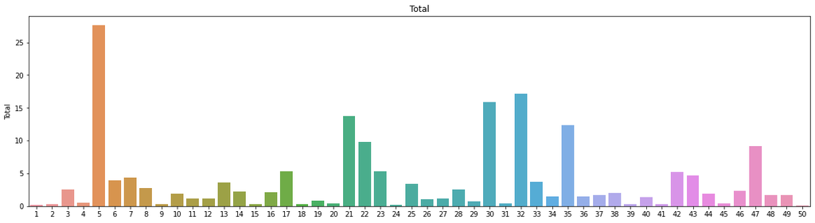

```python
fig, ax = plt.subplots(figsize=(20, 5))
sns.barplot(ax = ax, y = df_gbstate["Total"], x = np.int32(np.linspace(1,50,50))).set_title("Total")
print("The states are in alphabetical order")
for i in range(1, 50):
    print("The number {} indicates state: {}".format(i, list(df_gbstate.index)[i]))
```

## Predicting outcomes based on machine learning models

First, we will prepare the data for our ML testing by adding dummy variables for categoricals.

```python
import sklearn.preprocessing as sklp
from sklearn.preprocessing import RobustScaler
categorical = ['State', 'Agency_type', 'Agency_name']
le = sklp.LabelEncoder()

# creating dummy variable columns in our dataframe in order to predict them
for column in categorical:
    df[column] = le.fit_transform(df[column])

numerical = ['Race', 'Religion', 'Sexual_orientation', 'Ethnicity','Disability',
            'Gender', 'Gender_Identity', '1st_quarter', '2nd_quarter', '3rd_quarter', '4th_quarter', 'Population']

# Preprocessing the data
rc = RobustScaler()
df[numerical] = rc.fit_transform(df[numerical])

total = np.array(df["Race"]) + np.array(df["Religion"]) + np.array(df["Sexual_orientation"]) + np.array(df["Ethnicity"]) + np.array(df["Disability"]) + np.int32(df["Gender"]) + np.int32(df["Gender_Identity"])
df["Total"] = total

# X = pd.concat( [df["State"], df["Agency_type"], df["Agency_name"], df["Population"]], axis=1, keys=["State", "Agency_type", "Agency_name", "Population"])
X = np.array(df["Population"]).reshape(-1,1)
y = np.array(df["Total"]).reshape(-1)
```

First, dividing the dataset into training set and testing set.

```python
from sklearn.model_selection import train_test_split
from sklearn.linear_model import LinearRegression
from sklearn.metrics import mean_squared_error

X_train, X_test, y_train, y_test = train_test_split(X, y, test_size = 0.3, random_state = 12)
X_train.shape, X_test.shape
```

```
((960, 1), (412, 1))
```

```python
lr = LinearRegression()
lr.fit(X_train, y_train)

y_test_lr = lr.predict(X_test)
y_train_lr = lr.predict(X_train)

acc_train_lr = lr.score(X_train, y_train)
acc_test_lr = lr.score(X_test, y_test)

rmse_train_lr = np.sqrt(mean_squared_error(y_train, y_train_lr))
rmse_test_lr = np.sqrt(mean_squared_error(y_test, y_test_lr))

print("Linear Regression: Accuracy on training Data: {:.3f}".format(acc_train_lr))
print("Linear Regression: Accuracy on test Data: {:.3f}".format(acc_test_lr))
print('\nLinear Regression: The RMSE of the training set is:', rmse_train_lr)
print('Linear Regression: The RMSE of the testing set is:', rmse_test_lr)
```

```
Linear Regression: Accuracy on training Data: 0.740
Linear Regression: Accuracy on test Data: 0.170

Linear Regression: The RMSE of the training set is: 5.9703285211151735
Linear Regression: The RMSE of the testing set is: 4.217547674212154
```

```python
from sklearn.tree import DecisionTreeRegressor

# instantiate the model
tree = DecisionTreeRegressor(max_depth=9)
# fit the model
tree.fit(X_train, y_train)

#predicting the target value from the model for the samples
y_test_tree = tree.predict(X_test)
y_train_tree = tree.predict(X_train)

#computing the accuracy of the model performance
acc_train_tree = tree.score(X_train, y_train)
acc_test_tree = tree.score(X_test, y_test)

#computing root mean squared error (RMSE)
rmse_train_tree = np.sqrt(mean_squared_error(y_train, y_train_tree))
rmse_test_tree = np.sqrt(mean_squared_error(y_test, y_test_tree))

print("Decision Tree: Accuracy on training Data: {:.3f}".format(acc_train_tree))
print("Decision Tree: Accuracy on test Data: {:.3f}".format(acc_test_tree))
print('\nDecision Tree: The RMSE of the training set is:', rmse_train_tree)
print('Decision Tree: The RMSE of the testing set is:', rmse_test_tree)
```

```
Decision Tree: Accuracy on training Data: 0.987
Decision Tree: Accuracy on test Data: -1.816

Decision Tree: The RMSE of the training set is: 1.3115354734181834
Decision Tree: The RMSE of the testing set is: 7.766354938097811
```

## Conclusions

Based on the results above, there is clearly no prediction between the population and the total number of hate crime incident occurences in the United States. It is hence wrong to predict the number of hate crimes based on the population of the area.